# Introduction to Quantum Computing

## Assignment 5 - Due March 21

### Quantum algorithms with IBM-Q

#### Instructions:

- All problems below should be solved with Qiskit using a Jupyter notebook in the UVic Jupyter hub: https://jhub-phys.uvic.ca.
- Once you’re done, submit your `.ipynb` file(s) to the A5 area in BrightSpace.

### Resources

- [UVic Jupyter Hub](https://jhub-phys.uvic.ca)
- [Qiskit Documentation](https://qiskit.org/documentation/)
- [IBM Quantum Lab](https://quantum-computing.ibm.com/)

```python
# Import usual python numerical library
import numpy as np
# Importing standard Qiskit libraries
from qiskit import *
from qiskit_aer import AerSimulator
from qiskit.quantum_info import Statevector, Pauli
from qiskit.visualization import plot_bloch_vector, plot_distribution
from qiskit_ibm_runtime import EstimatorV2, SamplerV2
from qiskit.compiler import transpile


import matplotlib
import matplotlib.pyplot
%matplotlib inline


import subprocess
#this is so I can run the code on my computer without sharing my token online
#you can get your own token at https://quantum-computing.ibm.com/account
token = subprocess.run("echo $IBM_TOKEN", shell=True, stdout=subprocess.PIPE).stdout.decode('utf-8').strip()

# Insert your token
from qiskit_ibm_runtime import QiskitRuntimeService

QiskitRuntimeService.save_account(
  token=token,
  channel="ibm_quantum", # `channel` distinguishes between different account types
  overwrite=True, set_as_default=True)

# List the backends available to you.
service = QiskitRuntimeService(channel="ibm_quantum")

# Load the backend with the fewest pending jobs
service_backend = service.least_busy()
print('Using backend:', service_backend.name)
```

```
Using backend: ibm_sherbrooke
```

## 1. Quantum Cryptography (BB84)

Write a Qiskit code that implements BB84 with 15 qubits. You will play Alice, and there is no eavesdropper.

### (a) Simulated Bob

- Use the `AerSimulator` to play Bob.
- State clearly the value of the one-time pad that you got.

### (b) Real Device Bob

- Use a real quantum device of your choice to play Bob.
- Clearly state the one-time pad that you got.
- Does it agree with the one-time pad that Alice got?
- Does it make sense to interpret the device’s intrinsic noise as an eavesdropper?

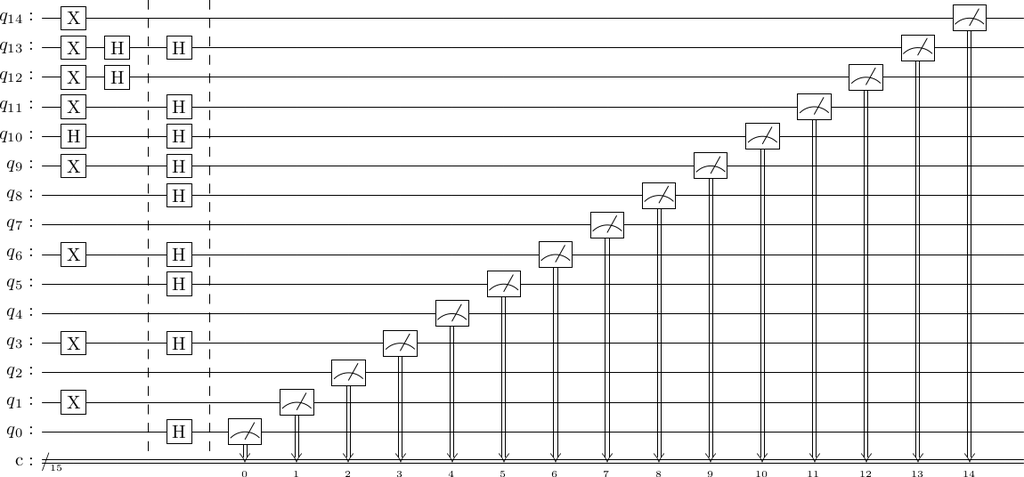

```
Alice's bits:		 [0 1 0 1 0 0 1 0 0 1 0 1 1 1 1]
Alice's bases:		 [0 0 0 0 0 0 0 0 0 0 1 0 1 1 0]
Bob's bases:		 [1 0 0 1 0 1 1 0 1 1 1 1 0 1 0]
Bob's measurements:	 [0 1 0 0 0 1 1 0 1 0 0 1 1 1 1]
Basis matches:		  ✗ ✓ ✓ ✗ ✓ ✗ ✗ ✓ ✗ ✗ ✓ ✗ ✗ ✓ ✓

Private key: 1000011
```

```python
# 1a. Implement BB84 protocol using AerSimulator.

qubit_count = 15

# Generate Alice's bases, followed by the qubits (logical 0 or 1)
alice_bases = np.random.randint(2, size=qubit_count)
alice_bits = np.random.randint(2, size=qubit_count)

#note that the basis 0 corresponds to the computational basis, and 1 corresponds to the Hadamard basis

# Generate Bob's bases
bob_bases = np.random.randint(2, size=qubit_count)




# Create a quantum circuit to represent the qubits

bb84 = QuantumCircuit(qubit_count, qubit_count)

# Alice prepares the qubits:
for i in range(qubit_count):
    if alice_bits[i] == 1:
        bb84.x(i) # |0> -> |1>, triggers iff. the bit is 1
    if alice_bases[i] == 1:
        bb84.h(i) # changes the measurement basis to the Hadamard basis if the basis is specified as logical 1.

bb84.barrier()

# Bob Measures:
for i in range(qubit_count):
    if bob_bases[i] == 1:
        bb84.h(i)

bb84.barrier()

bb84.measure(range(qubit_count), range(qubit_count))

display(bb84.draw('latex', reverse_bits=True))
# Run the simulation
simulator = AerSimulator()
result = simulator.run(bb84, memory=True).result()

print("Alice's bits:\t\t", alice_bits)
print("Alice's bases:\t\t", alice_bases)
print("Bob's bases:\t\t", bob_bases)

bob_measurements = result.get_memory()
bob_bits = bob_measurements[0]
formatted_bits = ' '.join(bob_bits)
formatted_bits = formatted_bits[::-1] # reverse the order of the bits to match the qubits
print("Bob's measurements:\t [" + formatted_bits + "]")

# We need to figure out which qubits Bob measured in the same basis as Alice

private_key = ''
for i in range(qubit_count):
    if alice_bases[i] == bob_bases[i]:
        private_key += str(bob_measurements[0][(qubit_count - 1) - i]) # if the bases match, we can add the bit to the private key. We have to do (qubit_count - 1) - i because the qubits are stored in reverse order in the memory.

# Print the results
matches = ['✓' if alice_bases[i] == bob_bases[i] else '✗' for i in range(qubit_count)]
matches = ' '.join(matches)
print("Basis matches:\t\t ", matches,)

print("\nPrivate key:", private_key)
```

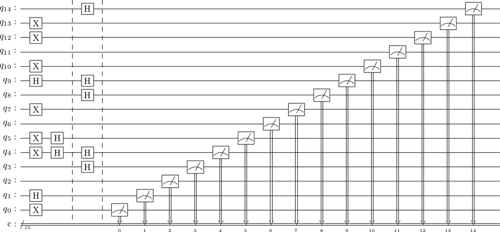

```
Alice's bits:		 [1 0 0 0 1 1 0 1 0 0 1 0 1 1 0]
Alice's bases:		 [0 1 0 0 1 1 0 0 0 1 0 0 0 0 0]
Bob's bases:		 [0 0 0 1 1 0 0 0 1 1 0 0 0 0 1]
Bob's measurements:	 [1 1 0 0 1 0 0 1 0 0 1 0 1 1 1]
Basis matches:		  ✓ ✗ ✓ ✗ ✓ ✗ ✓ ✓ ✗ ✓ ✓ ✓ ✓ ✓ ✗

Private key: 1010101011
```

```python
#  1b. Implement BB84 protocol using Real Hardware.

qubit_count = 15

# Generate Alice's bases, followed by the qubits (logical 0 or 1)
alice_bases = np.random.randint(2, size=qubit_count)
alice_bits = np.random.randint(2, size=qubit_count)

#note that the basis 0 corresponds to the computational basis, and 1 corresponds to the Hadamard basis

# Generate Bob's bases
bob_bases = np.random.randint(2, size=qubit_count)




# Create a quantum circuit to represent the qubits

bb84 = QuantumCircuit(qubit_count, qubit_count)

# Alice prepares the qubits:
for i in range(qubit_count):
    if alice_bits[i] == 1:
        bb84.x(i) # |0> -> |1>, triggers iff. the bit is 1
    if alice_bases[i] == 1:
        bb84.h(i) # changes the measurement basis to the Hadamard basis if the basis is specified as logical 1.

bb84.barrier()

# Bob Measures:
for i in range(qubit_count):
    if bob_bases[i] == 1:
        bb84.h(i)

bb84.barrier()

bb84.measure(range(qubit_count), range(qubit_count))

display(bb84.draw('latex', reverse_bits=True))
# Run the simulation
simulator = AerSimulator()
result = simulator.run(bb84, memory=True).result()

print("Alice's bits:\t\t", alice_bits)
print("Alice's bases:\t\t", alice_bases)
print("Bob's bases:\t\t", bob_bases)


# We need to transpile the circuit to match the device, and then send it over to the device for execution
bb84_transpiled = transpile(bb84, service_backend)
# optimize the circuit
bb84_pass_manager = generate_preset_pass_manager(backend=service_backend, optimization_level=2)


# send the job to the device
isa_bb84 = bb84_pass_manager.run(bb84_transpiled)
from qiskit_ibm_runtime import SamplerV2
service_backend = service.least_busy()
sampler = SamplerV2(service_backend)
# print('Using backend:', service_backend.name)
result_sampler = sampler.run([isa_bb84], shots=1).result() # we only want one shot- to simulate the real world scenario running the protocol once in real-time.



bob_bits = result_sampler[0].data.c.get_bitstrings()[0]

formatted_bits = ' '.join(bob_bits)
formatted_bits = formatted_bits[::-1] # reverse the order of the bits to match the qubits
print("Bob's measurements:\t [" + formatted_bits + "]")

# We need to figure out which qubits Bob measured in the same basis as Alice

private_key = ''
for i in range(qubit_count):
    if alice_bases[i] == bob_bases[i]:
        private_key += str(bob_bits[(qubit_count - 1) - i]) # if the bases match, we can add the bit to the private key. We have to do (qubit_count - 1) - i because the qubits are stored in reverse order in the memory.

# Print the results
matches = ['✓' if alice_bases[i] == bob_bases[i] else '✗' for i in range(qubit_count)]
matches = ' '.join(matches)
print("Basis matches:\t\t ", matches,)

print("\nPrivate key:", private_key)
```

### Discussion

#### Does it agree with the one-time pad that Alice got?

Running the code with the AerSimulator, the one-time pad that Bob got was the same as the one-time pad that Alice got. This is expected since there is no eavesdropper in this case.

Running on a real quantum device, the one-time pad that Bob got was also the same as the one-time pad that Alice got. This behaviour was observed both running a singe shot and multiple (8192) shots. This suggests that the device has adequate error-correction and noise mitigation techniques in place- the intrinsic noise of the device is not enough to cause a discrepancy between the one-time pads of Alice and Bob (at least for the number of qubits used in this case).

This experiment should be continued for a larger number of qubits to see if the intrinsic noise of the device starts to cause discrepancies between the one-time pads of Alice and Bob, and if so, at what point this occurs. This will form the basis of the "upper bound" tuning that Dr. De Sousa has mentioned in class.

#### Does it make sense to interpret the device’s intrinsic noise as an eavesdropper?

In this case, probably not. The device's intrinsic noise was not observed to produce discrepancies between the one-time pads of Alice and Bob. However, this is not always the case.

In general, the intrinsic noise of a quantum device can be considered as an eavesdropper if it is causing discrepancies between the one-time pads of Alice and Bob. (Which would occur if an eavesdropper was intercepting and measuring qubits.) This is why it is important to run the BB84 protocol on a real quantum device to test its security, and calibrate the device to ensure that the intrinsic noise is not enough to cause discrepancies between the one-time pads of Alice and Bob, but ensure the detection of an eavesdropper if one is present.

## 2. Quantum Cloning

### (a) Design a Quantum Cloning Circuit

Design a quantum circuit that clones the states $|+\rangle$ and $|-\rangle$, i.e., design a unitary $ U $ that achieves the following:

$$ U (|+\rangle |0\rangle) = |+\rangle |+\rangle, \\ U (|-\rangle |0\rangle) = |-\rangle | -\rangle. $$

### (b) Cloning Fidelity

- Apply this $ U $ to $|0\rangle$ and $|1\rangle$.
- Evaluate the "cloning fidelity" by computing:

$$ F_{\psi} = |\langle\psi| \langle\psi| U (|\psi\rangle |0\rangle)|^2 $$

for $|\psi\rangle = |0\rangle$ and $|\psi\rangle = |1\rangle$ using the `AerSimulator`. How good is the cloning?

```
Designed Unitary:
```

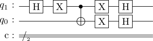

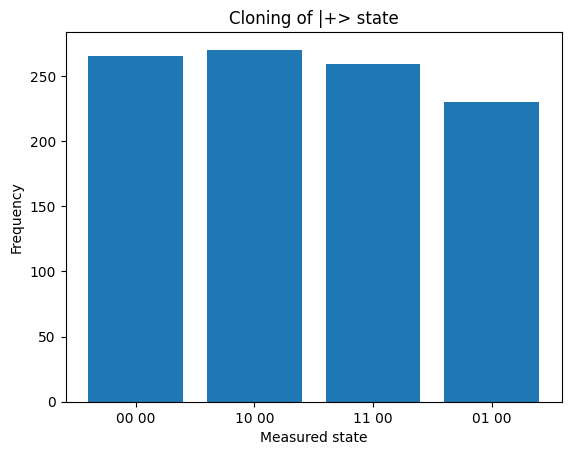

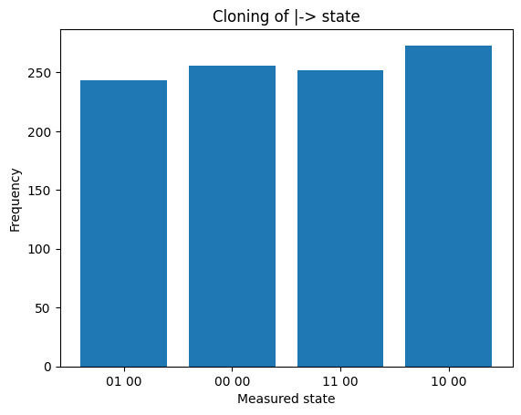

```python
# 2a. Design (and implement) a quantum circuit that clones the state of a qubit in the Hadamard basis.

qreg_q = QuantumRegister(2, 'q')
creg_c = ClassicalRegister(2, 'c')
hadamard_clone = QuantumCircuit(qreg_q, creg_c)

hadamard_clone.h(qreg_q[1])
hadamard_clone.x(qreg_q[1])
hadamard_clone.cx(qreg_q[1], qreg_q[0])
hadamard_clone.x(qreg_q[0])
hadamard_clone.x(qreg_q[1])
hadamard_clone.h(qreg_q[0])
hadamard_clone.h(qreg_q[1])



# Draw the designed Unitary
print("Designed Unitary:")
display(hadamard_clone.draw(reverse_bits=True, output='latex'))

# Run the simulation for states |+>|0> and |->|0>
simulator = AerSimulator()

# Prepare states |+>|0> and |->|0>

prepare_plus = QuantumCircuit(2, 0)
prepare_plus.h(1) # |0>|0> -> |+>|0>
prepare_plus.barrier(range(2))

prepare_minus = QuantumCircuit(2, 0)
prepare_minus.x(1) # |0>|0> -> |1>|0>
prepare_minus.h(1) # |1>|0> -> |->|0>
prepare_minus.barrier(range(2))

# Run 1. (State |+>|0>)
hadamardClone_plus = QuantumCircuit.compose(prepare_plus, hadamard_clone, range(2), range(2))
hadamardClone_plus.measure_all()
hadamardClone_plus.draw(reverse_bits=True, output='latex')
result_plus = simulator.run(hadamardClone_plus).result()


# Plot the results, showing the deterministic state of the cloned qubit (expecting |00> to correspond with cloned |++>).
counts_plus = result_plus.get_counts()
matplotlib.pyplot.bar(counts_plus.keys(), counts_plus.values())
matplotlib.pyplot.xlabel('Measured state')
matplotlib.pyplot.ylabel('Frequency')
matplotlib.pyplot.title('Cloning of |+> state')
matplotlib.pyplot.show()

# Run 2. (State |->|0>)
hadamardClone_minus = QuantumCircuit.compose(prepare_minus, hadamard_clone, range(2), range(2))
hadamardClone_minus.measure_all()
hadamardClone_minus.draw(reverse_bits=True, output='latex')
result_minus = simulator.run(hadamardClone_minus).result()
result_minus = simulator.run(hadamardClone_minus).result()

# Plot the results, showing the deterministic state of the cloned qubit (expecting |11> to correspond with cloned |-->).
counts_minus = result_minus.get_counts()
matplotlib.pyplot.bar(counts_minus.keys(), counts_minus.values())
matplotlib.pyplot.xlabel('Measured state')
matplotlib.pyplot.ylabel('Frequency')
matplotlib.pyplot.title('Cloning of |-> state')
matplotlib.pyplot.show()
```

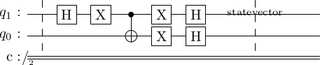

```
Fidelity of |00>: 0.0
```

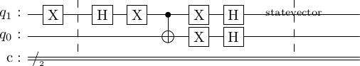

```
Fidelity of |10>: 0.4999999999999999
```

```python
# 2b. [Cloning Fidelity] Apply the cloning unitary to states |00> and |10> and measure the fidelity of the cloned states with the original states.
# This will use the given equation in the problem statement.

# Prepare states |00> and |10>
prepare_00 = QuantumCircuit(2, 0)
prepare_00.barrier(range(2))

prepare_10 = QuantumCircuit(2, 0)
prepare_10.x(1) # |00> -> |10>
prepare_10.barrier(range(2))

# Run 1. (State |00>)
hadamardClone_00 = QuantumCircuit.compose(prepare_00, hadamard_clone, range(2), range(2))
hadamardClone_00.save_statevector()
display(hadamardClone_00.draw(reverse_bits=True, output='latex'))
result_00 = simulator.run(hadamardClone_00).result()
# print(result_00.get_statevector())

# Calculate the fidelity

# F = |<0<0|U(|0>|0>)|^2

ket_00 = np.array([0, 0, 0, 0])

fidelity_00 = np.abs(np.dot(ket_00.conj(), result_00.get_statevector() ))**2
print("Fidelity of |00>:", fidelity_00)

# Run 2. (State |10>)
hadamardClone_10 = QuantumCircuit.compose(prepare_10, hadamard_clone, range(2), range(2))
hadamardClone_10.save_statevector()
display(hadamardClone_10.draw(reverse_bits=True, output='latex'))
result_10 = simulator.run(hadamardClone_10).result()
# print(result_10.get_statevector())

# Calculate the fidelity

# F = |<1<0|U(|1>|0>)|^2

ket_10 = np.array([0, 0, 1, 0])

fidelity_10 = np.abs(np.dot(ket_10.conj(), result_10.get_statevector() ))**2
print("Fidelity of |10>:", fidelity_10)
```

### Discussion

[1] M. Iqbal, L. Velasco, N. Costa, A. Napoli, J. Pedro, and M. Ruiz, “Investigating Imperfect Cloning for Extending Quantum Communication Capabilities,” Sensors, vol. 23, no. 18, Art. no. 18, Jan. 2023, doi: 10.3390/s23187891.

## 3. One-Qubit Tomography

Write the three circuits necessary to measure the projections of the state:

$$ |\psi\rangle = \cos\left(\frac{\pi}{8}\right) |0\rangle + \sin\left(\frac{\pi}{8}\right) |1\rangle, $$

along the x, y, and z axes of the Bloch sphere.

- Do this for the simulator and for a real device using **1000 shots**.
- Use the function `plot_bloch_vector([px,py,pz])` to display the Bloch vectors.
- How do they compare?

```
Expectation values (Aer): 0.7071067811865476 0.0 0.7071067811865475
```

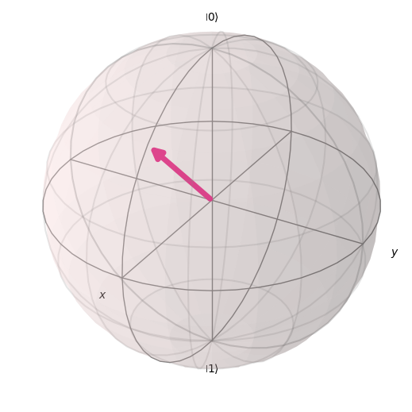

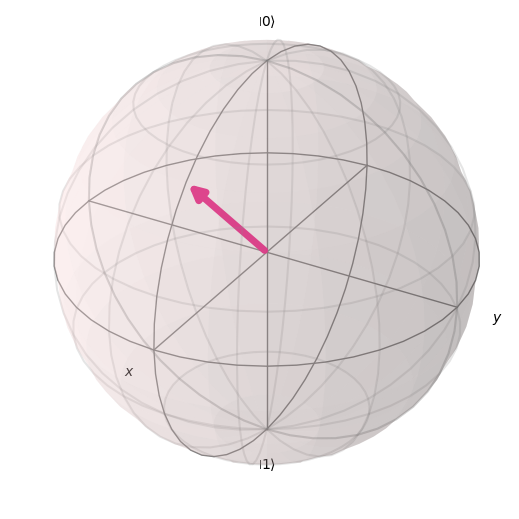

```python
# [One-Qubit Tomography] essentially, just plot \ket{\psi} in the Bloch sphere. Do this in the simulator and on a real device.

# Here's the plan:
# 1. Generate the state \ket{\psi} as defined in the problem definition.
# 2. do <psi|U|psi> on each of the pauli matrices to get the expectation values on each of the axes of the Bloch sphere.
# Note: this is where "real device" and "simulator" will differ, as we should expect some noise running U|psi> on a real device.
# 3. Expectation values in hand, we can plot the Bloch vectors.

# Simulating the output using Qiskit.quatum_info.Statevector
psi_generator = QuantumCircuit(1, 1)
psi_generator.ry(np.pi/4, 0) # |0> -> |psi>
psi_generator.barrier(range(1))
state_psi = Statevector.from_instruction(psi_generator)

# Defining the circuit to run on the real device (or simulator)
circ_x = QuantumCircuit.copy(psi_generator)
circ_x.x(0) # apply the X gate to the qubit, performing X|psi>
circ_x.save_statevector() # we need this to perform the expectation value calculation

circ_y = QuantumCircuit.copy(psi_generator)
circ_y.y(0) # apply the Y gate to the qubit, performing Y|psi>
circ_y.save_statevector() # we need this to perform the expectation value calculation

circ_z = QuantumCircuit.copy(psi_generator)
circ_z.z(0) # apply the Z gate to the qubit, performing Z|psi>
circ_z.save_statevector() # we need this to perform the expectation value calculation

# Run the circuits on the simulator
simulator = AerSimulator()

aer_expectation_x = simulator.run(circ_x).result().get_statevector().expectation_value(Pauli('X'))
aer_expectation_y = simulator.run(circ_y).result().get_statevector().expectation_value(Pauli('Y'))
aer_expectation_z = simulator.run(circ_z).result().get_statevector().expectation_value(Pauli('Z'))

print("Expectation values (Aer):", aer_expectation_x, aer_expectation_y, aer_expectation_z)

plot_bloch_vector([aer_expectation_x, aer_expectation_y, aer_expectation_z])
```

```
Using backend: ibm_sherbrooke
Expectation values (Real Hardware): [0.71996548 0.         0.71799297]
```

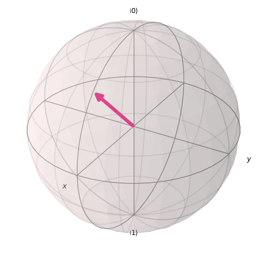

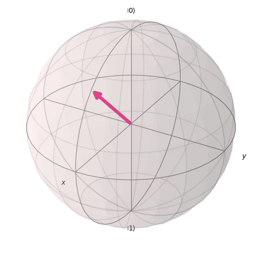

```python
# The below code is adapted from the example provided in the Qiskit documentation.
# https://docs.quantum.ibm.com/api/qiskit-ibm-runtime/estimator-v2

psi = psi_generator
service_backend = service.least_busy()
# Transpile the circuit to match the device
pm = generate_preset_pass_manager(backend=service_backend, optimization_level=3)
isa_psi = pm.run(psi)

# Define the observables
isa_observables = []
isa_observables.append(Pauli('X').apply_layout(isa_psi.layout))
isa_observables.append(Pauli('Y').apply_layout(isa_psi.layout))
isa_observables.append(Pauli('Z').apply_layout(isa_psi.layout))

print('Using backend:', service_backend.name)
estimator = EstimatorV2(mode=service_backend, options={"default_shots": 1000})

# calculate [ <psi|hamiltonian|psi> ]
job = estimator.run([(isa_psi, isa_observables)])
pub_result = job.result()[0]
print(f"Expectation values (Real Hardware): {pub_result.data.evs}")

plot_bloch_vector(pub_result.data.evs)
```

```python
# plot both the Bloch vectors side by side for comparison
# this is not possible using the plot_bloch_vector function, so we'll use the kaleidoscope library instead.
from kaleidoscope import bloch_sphere
import numpy as np

# normalize the vectors so kaleidoscope can plot them (for some reason pub_result.data.evs is not normalized)
simulator_vector = np.array([float(aer_expectation_x), float(aer_expectation_y), float(aer_expectation_z)])
real_device_vector = np.array(pub_result.data.evs)

simulator_vector = simulator_vector / np.linalg.norm(simulator_vector)
real_device_vector = real_device_vector / np.linalg.norm(real_device_vector)


bloch_sphere(vectors=(simulator_vector, real_device_vector))

# I like kaleidoscope's visualization better, as you can pan and zoom around the Bloch sphere.
```

[interactive chart not shown]

### Discussion.

We see that the projections along the x, y, and z axes of the Bloch sphere (in both simulator and real device) are consistent with our expectations for the state $|\psi\rangle$. (That is, we expected to see the state $|0\rangle$ being rotated over the y-axis by $\frac{\pi}{4}$).

The Bloch vectors for the simulator and real device are very similar, with small discrepancies likely due to the intrinsic noise of the real device. The Bloch vectors for the real device are slightly more "noisy" than the simulator, but the direction of the Bloch vectors are consistent with the expected values computed by the AerSimulator.

## 4. Error Correction with the Three-Qubit Bit-Flip Code

The circuit shown below is the “automated” version of the three-qubit bit-flip error correction code described in class. The last five gates – Two CNOTs and three Toffolis – perform the same **correction protocol** achieved by the conditional measurement operations shown in class.

- The final state $|\Phi\rangle$ of the ancillas remains $|00\rangle$ if no error happens.
- It becomes $|10\rangle, |11\rangle, |01\rangle$ when one of the qubits 2, 1, 0 flips, respectively.
- If another round of error correction is needed, the ancilla state $|\Phi\rangle$ must be reset to $|00\rangle$.

### (a) Implement the Algorithm

- Implement the algorithm for:

$$ |\psi_{\text{in}}\rangle = \frac{1}{\sqrt{2}} (|000\rangle + |111\rangle) $$

- In the simulator, check that it works by intentionally flipping each one of the three qubits in $|\psi_{\text{in}}\rangle$ before the error correction procedure.
- Measure $|\psi_{\text{out}}\rangle$ in the computational basis and check that you get close to 50% probability for **000** and **111**.

### (b) Run on a Real Device

- Run the same circuit in a **real device** (no need to add intentional flips!).
- Measure $|\psi_{\text{out}}\rangle$. How good is it?

### (c) Compare Without Error Correction

- Run the same algorithm in the same real device **without** the last five “correction protocol” gates.
- How do the computational basis probabilities for $|\psi_{\text{out}}\rangle$ compare to those found in item (b)?
- Conclude whether the device has low enough noise to benefit from error correction.

```
Generating experiment 1 with input state |+>|->|+>
```

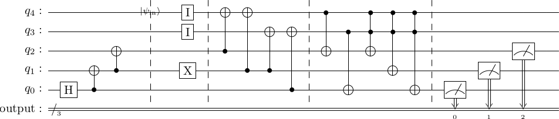

```
Sim {'000': 3943, '111': 4057}
Generating experiment 2 with input state |+++>
```

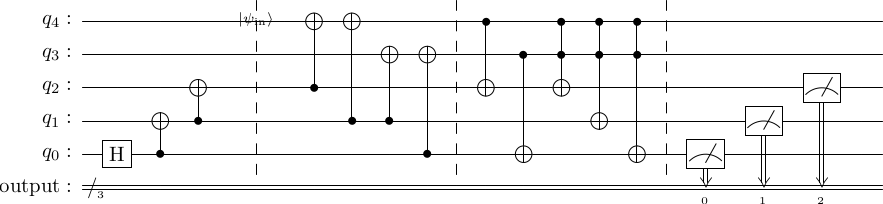

```
Generating experiment 3 with input state |+++>, and no error correction
```

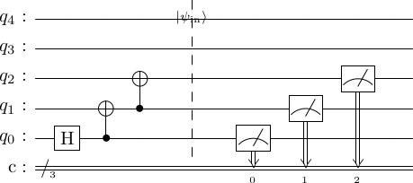

```
Running on ibm_sherbrooke
Real Hardware {'100': 1782, '000': 1330, '010': 1549, '110': 1207, '001': 540, '101': 464, '111': 598, '011': 530}
Hardware - No Error Correction {'110': 126, '000': 3543, '111': 3812, '010': 194, '001': 98, '011': 71, '100': 81, '101': 75}
```

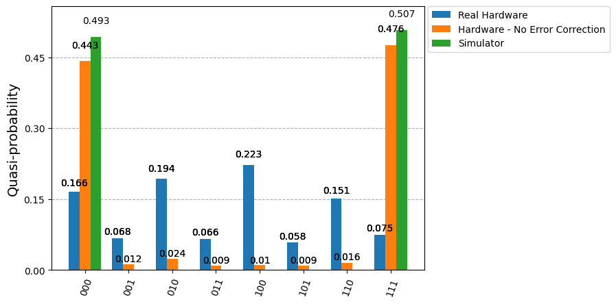

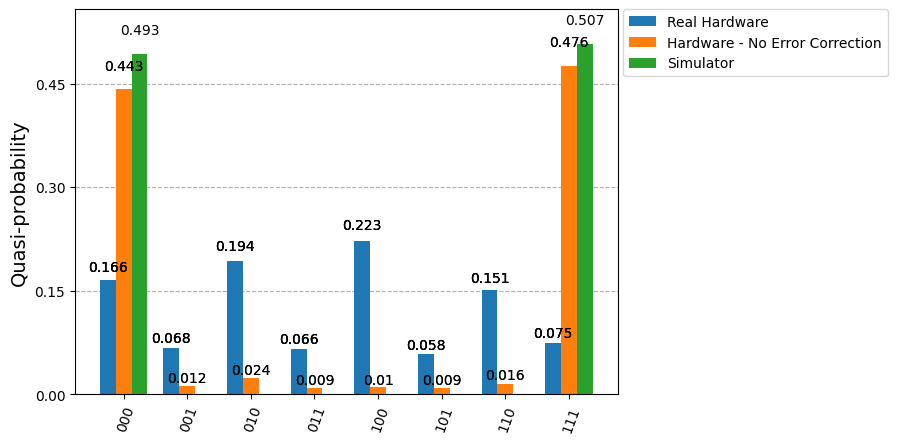

```python
# 4a.

service_backend = service.least_busy()

psi_in = QuantumCircuit(5, 0)
psi_in.h(0)
psi_in.cx(0, 1)
psi_in.cx(1, 2)


psi_in.barrier(range(5), label="\ket{\psi_{in}}") # |+++> with ancilla qubits in |0> state



qr = QuantumRegister(3, name="input")
anc = AncillaRegister(2, name="ancilla")
out = ClassicalRegister(3, name="output")

# Create a quantum circuit for diagnosis
error_diagnosis = QuantumCircuit(qr, anc, out)
error_diagnosis.cx(qr[2], anc[1])
error_diagnosis.cx(qr[1], anc[1])
error_diagnosis.cx(qr[1], anc[0])
error_diagnosis.cx(qr[0], anc[0])
error_diagnosis.barrier(range(5))

# Apply the error correction

error_correction = QuantumCircuit(qr, anc, out)

error_correction.cx(anc[1], qr[2])
error_correction.cx(anc[0], qr[0])
error_correction.ccx(anc[0], anc[1], qr[2])
error_correction.ccx(anc[0], anc[1], qr[1])
error_correction.ccx(anc[0], anc[1], qr[0])
error_correction.barrier(range(5))



# Measure the qubits
error_correction.measure(qr, out)


# prepare the input state
def generate_input_state(state: str) -> QuantumCircuit:
    input_state = QuantumCircuit(5, name="input_state")
    for i in range(len(state)):
        if state[i] == '1':
            input_state.x(i)
    input_state.id(3) # ensure the ancilla qubits are in the |0> state and remain untouched
    input_state.id(4)

    input_state.barrier(range(5))
    return input_state

print("Generating experiment 1 with input state |+>|->|+>")

# generate a five-qubit state that has a bit flip error on one of the qubits
experiment = QuantumCircuit.compose(QuantumCircuit.compose(psi_in, generate_input_state('010')), QuantumCircuit.compose(error_diagnosis, error_correction))

display(experiment.draw(reverse_bits=True, output='latex'))


pm = generate_preset_pass_manager(backend=service_backend, optimization_level=1)


# Run the experiment on the real device
simulator = AerSimulator(target=service_backend)
sampler = SamplerV2(simulator)
sim_result = simulator.run(experiment, shots=8000).result()

print("Sim", sim_result.get_counts())

# Run the experiment on the device
sampler = SamplerV2(service_backend)
print("Generating experiment 2 with input state |+++>")
experiment2 = QuantumCircuit.compose(psi_in, QuantumCircuit.compose(error_diagnosis, error_correction)) #note that we don't sim a bit flip on real hardware
display(experiment2.draw(reverse_bits=True, output='latex'))
isa_experiment2 = pm.run(experiment2)

measure_3 = QuantumCircuit(5, 3)
measure_3.measure(range(3), range(3))

print("Generating experiment 3 with input state |+++>, and no error correction")
experiment3 = QuantumCircuit.compose(psi_in, measure_3) #note that we don't sim a bit flip on real hardware
display(experiment3.draw(reverse_bits=True, output='latex'))
isa_experiment3 = pm.run(experiment3)
print("Running on", service_backend.name)


job = sampler.run([isa_experiment2, isa_experiment3], shots=8000)

# job = service.job('czgwngezj67g008seeng')
result = job.result() # run this after class is over, hopefully the job will be done by then.


# print(dir(result[1].data.c.get_counts()))

print("Real Hardware", result[0].data.output.get_counts())
print("Hardware - No Error Correction", result[1].data.c.get_counts())




plot_distribution([result[0].data.output.get_counts(), result[1].data.c.get_counts(), sim_result.get_counts()] , legend=['Real Hardware', 'Hardware - No Error Correction', 'Simulator'])
```

### Discussion

#### 4b)

The results of running the circuit on a real device show that the computational basis probabilities for $|\psi_{\text{out}}\rangle$ are not close to 50% for **000** and **111**. This suggests that the device has too much noise to benefit from error correction.

#### 4c)

This is further confirmed by running the same algorithm on the same real device without the last five "correction protocol" gates. The computational basis probabilities for $|\psi_{\text{out}}\rangle$ are much closer to 50% for **000** and **111** in this case. We may conclude that the device has too much noise to benefit from error correction, and it is advantageous to prefer a more concise circuit in most real-world applications.

## 5. Three-Bit Phase Estimation

### (a) Implement Phase Estimation

Implement the circuit below for $ U = R_y(\theta) $ with:

$$ \frac{\theta}{4\pi} = 0.j_1j_2j_3, $$

where **$ j_1j_2j_3 $** is your choice of three base-2 decimals.

- Note that $ \frac{\theta}{4\pi} $ is the associated phase **$ \phi_u $** for $|u\rangle = |-i\rangle$, since:

$$ R_y(\theta) |-i\rangle = e^{+i\frac{\theta}{2}} |-i\rangle = e^{+2\pi i \frac{\theta}{4\pi}} |-i\rangle. $$

- Input $|\psi\rangle = |-i\rangle$.
- Run the circuit in **both the simulator and a real device** to compare.

### (b) Small Perturbation

- Run the circuit again for $ \frac{\theta}{4\pi} = 0.j_1j_2j_3 - \epsilon $, with **$ \epsilon $** small.
- If you run the circuit many times, does it return the **$ 0.j_1j_2j_3 $** closest to the correct answer **$ \frac{\theta}{4\pi} $**?
- How does the real device compare to the simulator?

```
Running on ibm_sherbrooke
Real Hardware {'001': 324, '011': 517, '101': 4760, '110': 1064, '111': 271, '100': 451, '000': 713, '010': 92}
Simulator {'100': 129, '111': 22, '110': 127, '101': 746}
```

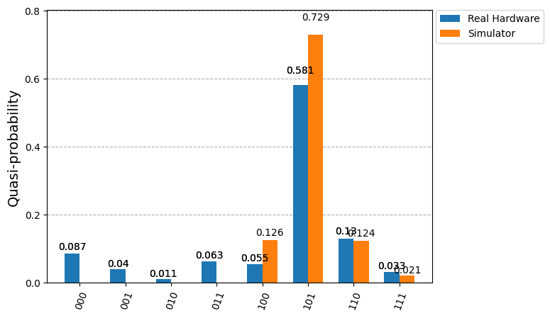

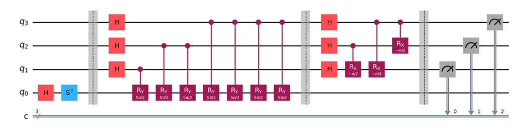

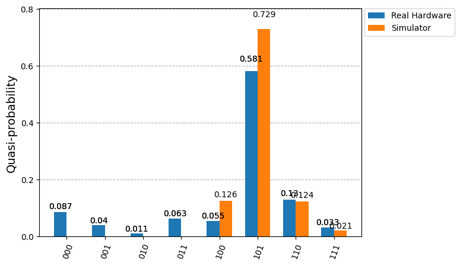

```python
# 3-bit phase esimation.

theta = (4*np.pi) * 0.625 # equivalent to 4*pi * 0b.101


# circuit with |-i> input
circ_qpe = QuantumCircuit(4, 3)
# prepare |-i> state:
circ_qpe.h(0)
circ_qpe.sdg(0)
circ_qpe.barrier(range(4))


# circuit:
circ_qpe.h(range(1, 4))
circ_qpe.cry(theta, 1, 0)

for i in range(0, 2):
    circ_qpe.cry(theta, 2, 0) # equiv to U^2
for i in range(0, 4):
    circ_qpe.cry(theta, 3, 0) # equiv to U^4

circ_qpe.barrier(range(4))
circ_qpe.h(range(1, 4))

circ_qpe.crx(-np.pi/2, 2, 1)
circ_qpe.crx(-np.pi/4, 3, 1)
circ_qpe.crx(-np.pi/2, 3, 2)

circ_qpe.barrier(range(4))
circ_qpe.measure(range(1, 4), range(3))

circ_qpe.draw(reverse_bits=True, output="mpl")

simulator = AerSimulator()
sim_job = simulator.run(circ_qpe)
sim_result = sim_job.result()



# Run the circuit on the real device
service_backend = service.least_busy()
pm = generate_preset_pass_manager(backend=service_backend, optimization_level=3)
isa_qpe = pm.run(circ_qpe)
sampler = SamplerV2(service_backend)
print("Running on", service_backend.name)
job = sampler.run([isa_qpe], shots=8192)
result = job.result()

print("Real Hardware", result[0].data.c.get_counts())
print("Simulator", sim_result.get_counts())

plot_distribution([result[0].data.c.get_counts(), sim_result.get_counts()], legend=['Real Hardware', 'Simulator'])
```

```
Running on ibm_sherbrooke
Real Hardware {'101': 3838, '011': 1207, '110': 1035, '010': 188, '100': 774, '111': 937, '000': 77, '001': 136}
Simulator {'100': 147, '111': 21, '101': 732, '110': 124}
```

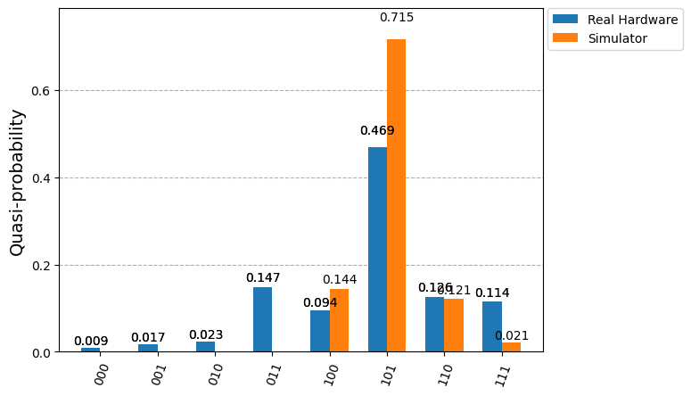

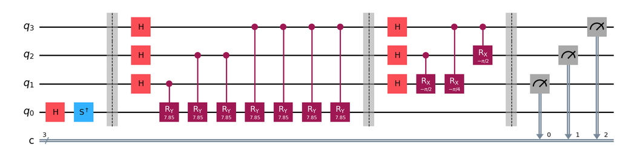

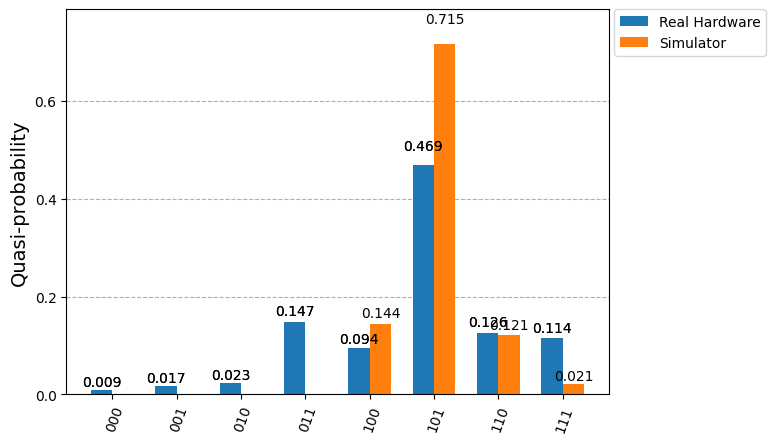

```python
# b)

# 3-bit phase esimation, with a small error in the phase.

theta = (4*np.pi) * 0.625 # equivalent to 4*pi * 0b.101

epsilon = 0.0005

theta = theta - epsilon

# circuit with |-i> input
circ_qpe = QuantumCircuit(4, 3)
# prepare |-i> state:
circ_qpe.h(0)
circ_qpe.sdg(0)
circ_qpe.barrier(range(4))


# circuit:
circ_qpe.h(range(1, 4))
circ_qpe.cry(theta, 1, 0)

for i in range(0, 2):
    circ_qpe.cry(theta, 2, 0) # equiv to U^2
for i in range(0, 4):
    circ_qpe.cry(theta, 3, 0) # equiv to U^4

circ_qpe.barrier(range(4))
circ_qpe.h(range(1, 4))

circ_qpe.crx(-np.pi/2, 2, 1)
circ_qpe.crx(-np.pi/4, 3, 1)
circ_qpe.crx(-np.pi/2, 3, 2)

circ_qpe.barrier(range(4))
circ_qpe.measure(range(1, 4), range(3))

circ_qpe.draw(reverse_bits=True, output="mpl")

simulator = AerSimulator()
sim_job = simulator.run(circ_qpe)
sim_result = sim_job.result()



# Run the circuit on the real device
service_backend = service.least_busy()
pm = generate_preset_pass_manager(backend=service_backend, optimization_level=3)
isa_qpe = pm.run(circ_qpe)
sampler = SamplerV2(service_backend)
print("Running on", service_backend.name)
job = sampler.run([isa_qpe], shots=8192)

result = job.result()

print("Real Hardware", result[0].data.c.get_counts())
print("Simulator", sim_result.get_counts())

plot_distribution([result[0].data.c.get_counts(), sim_result.get_counts()], legend=['Real Hardware', 'Simulator'])
```